# Extensions to the Grammar of Graphics

Package ‘ggpp’ 0.6.0.9000

Pedro J. Aphalo

2026-06-30

## Preliminaries

We load all the packages used in the examples, if installed, and set flags to skip examples if they are not available.

```r
library(ggpp)
library(tibble)
library(dplyr)
eval_magick <- requireNamespace("magick", quietly = TRUE)
```

We also set an uncluttered theme as default for ‘ggplot2’.

```r
old_theme <- theme_set(theme_bw() + theme(panel.grid = element_blank()))
```

# Introduction to the extensions

## Data labels, annotations and insets

*Data labels* add textual information directly related to individual data points (shown as glyphs). Text position in this case is dependent on the scales used to represent data points. Text is usually displaced so that it does not occlude the glyph representing the data point and when the link to the data point is unclear, this link is signaled with a line segment or arrow. Data labels are distinct from annotations but instead contribute to the representation of data on a plot or map.

*References* are lines, shading or marks used to help the reading of a plot. These elements are used to highlight specific values on an axis or a region in a plot. They, like data labels, are positioned relative to the scales used for data. The position of data labels and lines, glyphs or shading used as reference cannot be altered by the designer of a plot, as the position conveys information. I will use the term *data labels* irrespective if the “labels” are textual or graphical, like icons and small plots and simple tables linked to data points or map features.

According to Koponen and Hildén (2019), in a statistical chart “annotations can be used to draw reader attention to relevant detail”. These authors use as an example a text box in a plot to highlight a data point that is off-scale and has been “squeezed” to a position immediately outside the plotting area.

*Annotations* differ from data labels, in that their position is decoupled from their meaning. Insets can be thought as larger, but still self-contained annotations. In most cases the reading of inset tables and plots depends only weakly on the plot or map in which they are included.

In the case of annotations and insets the designer of a data visualization has the freedom to locate them anywhere, as long as they do not occlude features used to describe data. I will use the term *annotation* irrespective if the “labels” are textual or graphical. Insets are similar to annotations, but the term *inset* is used when an annotation’s graphical or textual element is complex and occupies more space within the plotting area. Insets can be moved from within the main plotting area to being adjacent to it, e.g., as a smaller panel, without any loss of meaning .

That the position of annotations and insets is independent of the plotted data cannot be expressed using the grammar of graphics (GG) as implemented in package ‘ggplot2’.

## Annotations in ‘ggplot2’

The plotting of data using package ‘ggplot2’ is described by Wickham (2016) and several other books. Chapter 7 in Aphalo (2020) not only describes the grammar used by ‘ggplot2’ but also several extensions to it, including those provided by packages ‘ggpp’ and ‘ggpmisc’ at the time of writing.

From the data visualization perspective the main practical and conceptual difference between data labels and annotations is in the scales used to position them within the plotting area. Instead of using an `annotate()` function that deviates from the grammar of graphics to implement annotations, we can retain the use of the grammar of graphics for annotations but add support for native plot coordinates (npc). Support of annotations done in this way allows “annotation layers” to behave almost identically to “data layers”, and use the same syntax. The *x* and *y* position aesthetics used for data can be supplemented with pseudo-aesthetics without any translation relative to the native plotting coordinates of the plotting area or viewport. Doing so, allows the graphic design flexibility conceptually inherent to annotations within a user-friendly syntax.

## Support of native plot coordinates

Based on this insight, a new approach to adding annotations and insets was implemented in package ‘ggpmisc’ (>= 0.3.1) through two new *x* and *y* pseudo-aesthetics, *npcx* and *npcy*, and corresponding dumb scales and various geometries that make use of them. These scales and geometries were are currently in package ‘ggpp’ and still used in package ‘ggpmisc’.

Native plot coordinates have range 0..1. However, the “npc” geoms from ‘ggpp’ also recognize certain positions by name with the same character strings as used for text justification in ‘ggplot2’. The default justification is `"inward"`, as this protects from clipping at the edges the plotting area irrespective of the arguments passed to the `witdth` and `height` parameters of R’s graphic devices.

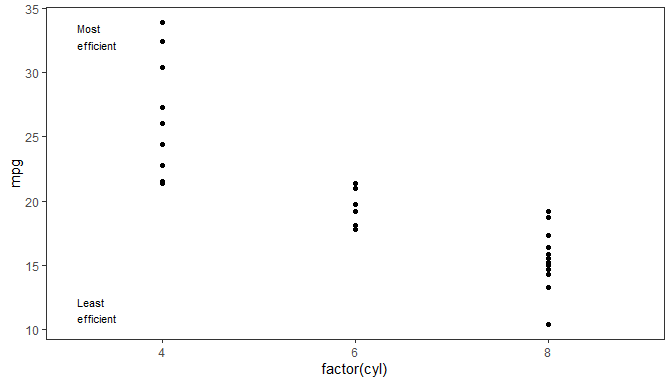

```r
p1 <- ggplot(mtcars, aes(factor(cyl), mpg)) +
  geom_point() +
  geom_text_npc(data = data.frame(x = c("left", "left"),
                                  y = c("top", "bottom"),
                                  label = c("Most\nefficient",
                                            "Least\nefficient")),
                mapping = aes(npcx = x, npcy = y, label = label),
                size = 3)
p1
```

The advantage of this approach becomes apparent when the limits of the *y* scale are unknown or vary. When a script or user defined plotting function sets the scale limits based on the input data, in the absence of the extensions proposed here, setting annotations consistently within the plotting area becomes laborious. The example below, shows how the annotations remain at the desired position when the *y* scale limits are expanded.

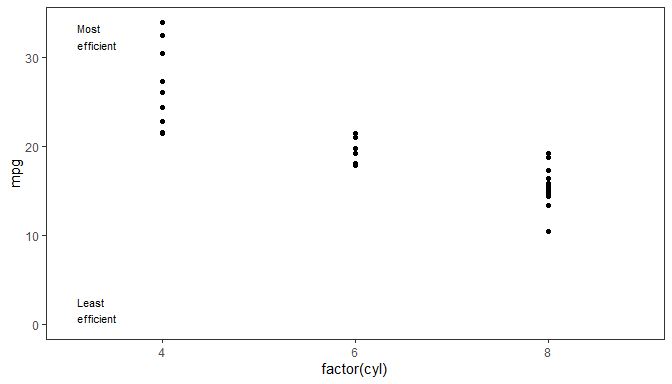

```r
p1 + expand_limits(y = 0)
```

To support the existing syntax for annotations using the new geometries, function `ggplot2::annotate()` is overridden when package ‘ggpp’ is loaded. The new definition adds support for the new pseudo-aesthetics *npcx* and *npcy* retaining its original ‘ggplot2’ behaviour in all other respects.

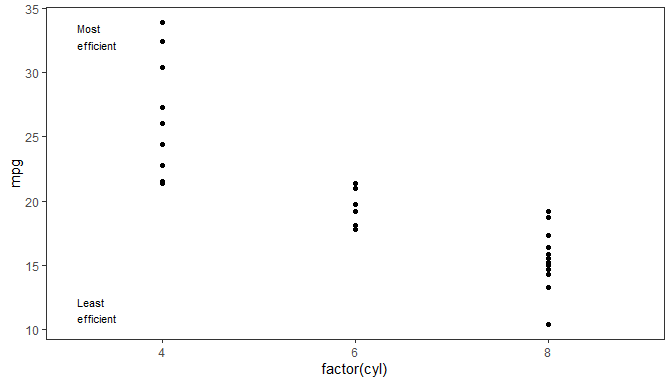

```r
ggplot(mtcars, aes(factor(cyl), mpg)) +
  geom_point() +
  annotate(geom = "text_npc",
           npcx = c("left", "left"),
           npcy = c("top", "bottom"),
           label = c("Most\nefficient",
                     "Least\nefficient"),
           size = 3)
```

Inset plots can be added with the same syntax using `geom_plot_npc()`. They can be thought also as being annotations. Here we use `annotate()` but `geom_plot()` can be also used directly, in which case the inset plots can be different for each panel.

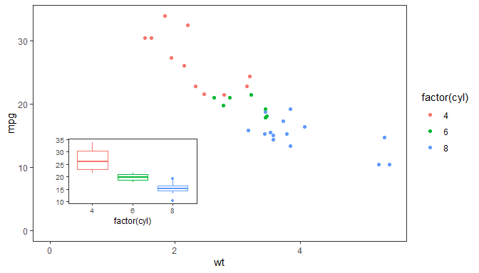

```r
p2 <- ggplot(mtcars, aes(factor(cyl), mpg, colour = factor(cyl))) +
  stat_boxplot() +
  labs(y = NULL) +
  theme_bw(9) +
  theme(legend.position = "none",
        panel.grid = element_blank())

ggplot(mtcars, aes(wt, mpg, colour = factor(cyl))) +
  geom_point() +
  annotate("plot_npc", npcx = "left", npcy = "bottom", label = p2) +
  expand_limits(y = 0, x = 0)
```

A simple example with facets, labelling of panels in a traditional way as required by some book and journal styles. In this case panel tags are added within the plotting area at a consistent “npc” location with free scale limits in panels.

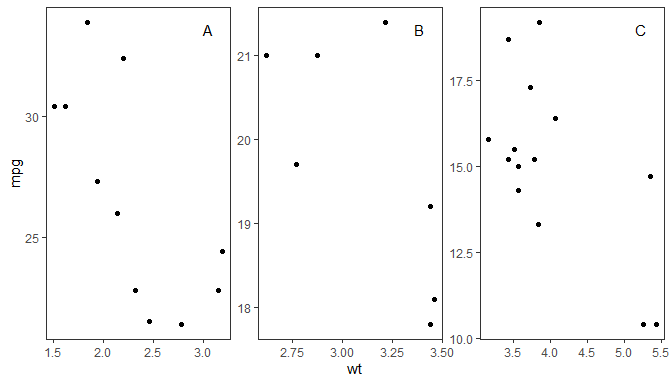

```r
ggplot(mtcars, aes(wt, mpg)) +
  geom_point() +
  geom_text_npc(data = data.frame(cyl = levels(factor(mtcars$cyl)),
                                  label = LETTERS[seq_along(levels(factor(mtcars$cyl)))],
                                  x = 0.90,
                                  y = 0.95),
                mapping = aes(npcx = x, npcy = y, label = label),
                size = 4) +
  facet_wrap(~factor(cyl), scales = "free") +
  theme(strip.background = element_blank(),
        strip.text = element_blank())
```

## When to use annotations and when insets

Package ‘ggpmisc’ adds support for various plot annotations and reference guides based on model fits and other statistics. It also adds support for some data labels related to data features. While developing these statistics in ‘ggpmisc’, it became clear that expanding the grammar of graphics’s support for annotations would simplify the new code considerably and also more cleanly separate the computations on data from the positioning of annotations. These extensions to the grammar are now in ‘ggpp’.

**Table**. Geometries useful for data labels and annotations. Currently implemented *ordinary* geometries and their *npc* versions. The rightmost column shows the expected class of the objects mapped to the `label` aesthetic. When using `annotate()` to add a single plot, table or grob as an inset, enclosing them in a list is allowed, but not a requirement. All those geoms whose names are highlighted in *`italics`* support plotting of connecting segments or arrows when a the coordinates have been modified by a *position* function.

**Table**. Geometries useful for data labels and annotations. Currently implemented *ordinary* geometries and their *npc* versions. The rightmost column shows the expected class of the objects mapped to the `label` aesthetic. When using `annotate()` to add a single plot, table or grob as an inset, enclosing them in a list is allowed, but not a requirement.

| Data labels | Annotations (npc) | `label` aes. |
| --- | --- | --- |
| `ggplot2::geom_text()` | `geom_text_npc()` | `character` |
| `ggplot2::geom_label()` | `geom_label_npc()` | `character` |
| `ggrepel::geom_text_repel()` |  | `character` |
| `ggrepel::geom_label_repel()` |  | `character` |
| `geom_text_s()` |  | `character` |
| `geom_label_s()` |  | `character` |
| `geom_text_pairwise()` |  | `character` |
| `geom_label_pairwise()` |  | `character` |
| `geom_point_s()` |  | *not supported* |
| `geom_plot()` | `geom_plot_npc()` | `list(<ggplot>)` |
| `geom_table()` | `geom_table_npc()` | `list(<data.frame>)` |
| `geom_grob()` | `geom_grob_npc()` | `list(<grob>)` |
| `geom_img()` *(planned)* | `geom_img_npc()` | `list(<raster>)` |

## Highlighting data features

Marginal annotations with symbols and vertical and horizontal lines can be used to highlight summary values or events/conditions. The *geoms* `geom_quadrant_lines()`, `geom_vhlines()`, `geom_x_margin_arrow()`, `geom_x_margin_grob()`, `geom_x_margin_point()`, `geom_y_margin_arrow()`, `geom_y_margin_grob()` and `geom_y_margin_point()` make such labelling easy. These work similarly to geoms `geom_hline()` and `geom_vline()` from ‘ggplot2’ and plays a similar role. Of course, they can also be used to add annotations not derived from the observations.

**Table**. Geometries useful for data labels and annotations, lines and marginal marks. The middle columns shows the aesthetic that determines the position of the lines or marks on the edge of the plotting area. The rightmost column shows the expected class of the objects mapped to the `label` aesthetic.

| Marginal marks | Location aesthetic | `label` aes. |
| --- | --- | --- |
| `geom_x_margin_arrow()` | `xintercept` | *not supported* |
| `geom_y_margin_arrow()` | `yintercept` | *not supported* |
| `geom_x_margin_grob()` | `xintercept` | `list(<grob>)` |
| `geom_y_margin_grob()` | `yintercept` | `list(<grob>)` |
| `geom_x_margin_point()` | `xintercept` | *not supported* |
| `geom_y_margin_point()` | `yintercept` | *not supported* |
| `geom_quadrant_lines()` |  | *not supported* |
| `geom_vhlines()` | `xintercept` `yintercept` | *not supported* |

When adding an informative element to a plot, assess whether it is an *annotation* or a *data label*. To decide on the best approach, consider if the location of the element is more “naturally” expressed in the original data units or as position relative to the edges or centre of the plotting area. In the second case, prefer the “npc” geoms as you are dealing with *annotations*, otherwise, use the ordinary geometries as you are dealing with data labels or data points.

## Summary statistics

With some types of data it is common to compute a summary per plot quadrant, rather than based on a prior grouping. The *stat* `stat_quadrant_counts()` can de used to annotate plots with the number of observations in each quadrant, selected quadrants, or quadrants pooled along *x* and/or *y*. Similarly, `stat_group_counts()` and `stat_panel_counts()` can be used to annotate plots with the number of observations per panel, or per group within each panel.

In many cases, such as rug plots or other representations on plot margins, *x* and *y* summaries can be computed in separate plot layers using the statistics from ‘ggplot2’. In contrast, in other cases, such as when showing the *x* and *y* position of the means in the plotting area itself, it is necessary to compute summaries for both *x* and *y* in the same plot layer. Function `stat_summary_xy()` is similar to `stat_summary()` from ‘ggplot2’ but useful when both *x* and *y* are continuous variables. It allows the use of the same, or different functions to summarize the data over *x* and *y*. In contrast, its simpler counterpart, `stat_centroid()`, always applies the same function over *x* and *y*.

An additional variation is statistic `stat_apply_group`, which can apply functions to *x* and *y* values in parallel, which is most useful for accumulating or differencing consecutive data values.

## Positioning data labels

Nudging is normally used to displace text labels so that data labels do not overlap the points or lines representing the data being labelled. Two enhanced versions of `position_nudge()` are provided, `position_nudge_center()` and `position_nudge_line()`. These functions make it possible to apply nudging that varies automatically according to the relative position of points with respect to arbitrary points or lines, or with respect to a polynomial or smoothing spline fitted on-the-fly to the the observations.

A limitation of ‘ggplot2’ is that only one position function can be used in a layer. This makes it difficult to add data labels to stacked or dodged bars or columns, or the labelling of points that have been jittered. The solution provided by ‘ggpp’ are wrappers on these position functions from ‘ggplot2’. These wrappers add support for nudging.

The position functions defined in ‘ggpp’, instead of deleting the original positions, rename the variables in `data` containing these coordinates. This makes it possible for geometries to draw connecting segments or arrows between old and new positions. For consistency, positions equivalent to all those defined in ‘ggplot2’ are defined in ‘ggpp’. These functions are backwards compatible with those from ‘ggplot2’ and can be used in place of them. The geometries from ‘ggrepel’ (>= 0.9.2) and many of those from ‘ggpp’ can make use of the original coordinates kept in data.

Position functions

| Position (origin kept) | Position (origin discarded) |
| --- | --- |
| `position_nudge_keep()` | `ggplot2::position_nudge()` |
| `ggrepel::postion_nudge_repel()` | `ggplot2::position_nudge()` |
| `position_nudge_centre()` |  |
| `position_nudge_line()` |  |
| `position_jitter_keep()` | `ggplot2::position_jitter()` |
| `position_dodge_keep()` | `ggplot2::position_dodge()` |
| `position_dodge2_keep()` | `ggplot2::position_dodge2()` |
| `position_stack_keep()` | `ggplot2::position_stack()` |
| `position_stack_minmax()` |  |
| `position_fill_keep()` | `ggplot2::position_fill()` |
| `position_jitternudge()` |  |
| `position_dodgenudge()` |  |
| `position_dodge2nudge()` |  |
| `position_stacknudge()` |  |
| `position_fillnudge()` |  |
| `position_jitterdodge_keep()` *(planned)* | `ggplot2::position_jitterdodge()` |
| `position_jitterdodgenudge()` *(planned)* |  |

There is a storage-use cost in saving the original position, by making the `data` member stored in the ggplot object bigger. This may need to be taken into consideration when `data` has many rows. In such cases, when a counterpart position function that does not keep the original coordinates exists, it is wise not to use the new “keep” position functions in combination with geometries that cannot make use of the additional information stored by them. Alternatively, and when using those new position functions with no counterpart in ‘ggplot2’ the keeping of the original position can be disabled by passing `kept.position = "none"` as an additional argument when they are called.

## Local density of observations

With stats from ‘ggplot2’ it is common to plot estimates of empirical density curves or empirical density surfaces. There are other uses for density estimates: 1) highlighting dense or sparse regions in clouds of observations plotted as points, and 2) using density to decide which observations to label and which not to label. _If the highlighting or labeling is to be interpreted as meaningful as a description of properties of the population then the fitted curve of surface should not be too flexible, it should not track local anomalies in the distribution of observations. In contrast if the use of the density estimate is only used as a way of avoiding overlaps among labels with no intent of describing properties of the data, much more flexible curves and surfaces are most effective.

Functions `stat_dens1d_filter()` and `stat_dens2d_filter()`, and `stat_dens1d_filter_g()` and `stat_dens2d_filter_g()` can be used to filter/subset data based on local density estimates.

Functions `stat_dens1d_labels()` and `stat_dens2d_labels()` instead of removing rows from data, replace or edit the values mapped to the `label` aesthetic before they are passed to the geometry. This is especially useful in combination with the repulsive geometries from package ‘ggrepel’ because by retaining all observations in data these geometries can repulse labels away from observations with and without data labels attached.

Although useful for diverse types of plots, these statistics are most useful when creating volcano and quadrant plots. A case where the observations near the edges of a cloud of observations are of special interest.

The density estimates used for the “filtering” of data rows or labels can be of interest both when selecting the parameters for the fit of the empirical density function or possibly even for mapping to an aesthetic. These are optionally returned.

One final twist is that even if the density estimate is in all cases obtained from the whole of `data`, the selection criteria can be applied separately, and even be different, for each quadrant or tail. For example, we can highlight or label the same fraction of observations, or alternatively the same number of observations in each quadrant or tail even if the overall density of observations is different between tails or among quadrants.

## ggplot methods

That `ggplot()` is defined as a generic method in ‘ggplot2’ makes it possible to define specializations. We provide two `ggplot()` methods for time series stored in objects of classes `ts` and `xts`. These methods automatically convert these objects into tibbles and set by default the aesthetic mappings for `x` and `y` automatically. A companion function `try_tibble()` is also exported.

## List of references

Aphalo, Pedro J. (2020) *Learn R: As a Language.* The R Series. Boca Raton and London: Chapman and Hall/CRC Press. ISBN: 978-0-367-18253-3. 350 pp.

Koponen, J; Hildén, J. (2019) *Data visualization handbook*. Aalto ARTS books, Espoo. ISBN 978-952-60-7449-8.

Wickham H. (2010) A Layered Grammar of Graphics. *Journal of Computational and Graphical Statistics* **19:** 3–28.

Wickham H. (2016) *ggplot2: Elegant Graphics for Data Analysis*. Springer International Publishing. ISBN 978-3-319-24275-0.

# Examples

Some of the examples below are evaluated only if packages ‘ggrepel’, and ‘magick’ are available.

## ggplot methods

`ggplot()` methods for classes `"ts"` and `"xts"` automate plotting of time series data, as *x* and *y* aesthetics are mapped to time and the variable of the time series, respectively. For plotting time series data stored in objects of other classes, see the conversion functions `try_tibble()` and `try_data_frame()` in the last section of this vignette.

By default, `time` is of class `Date` or of class `POSIXct` depending on how time is stored in the time series object. On-the-fly coversion of `time` to `numeric` is also possible (shown in the second example below).

```r
class(lynx)
```

```
## [1] "ts"
```

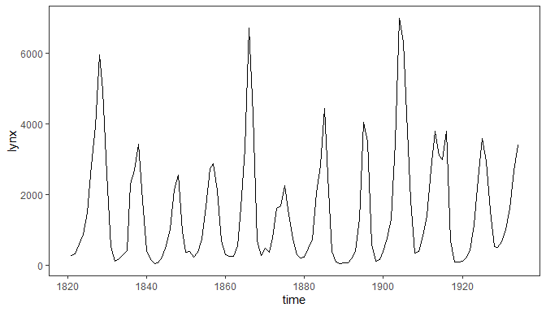

```r
ggplot(lynx) + geom_line()
```

The class of variable `time`, mapped to the *x* aesthetic, affects the scale used by default as well as the formatting of values when converted to character strings or printed. Here we force its conversion to `numeric`.

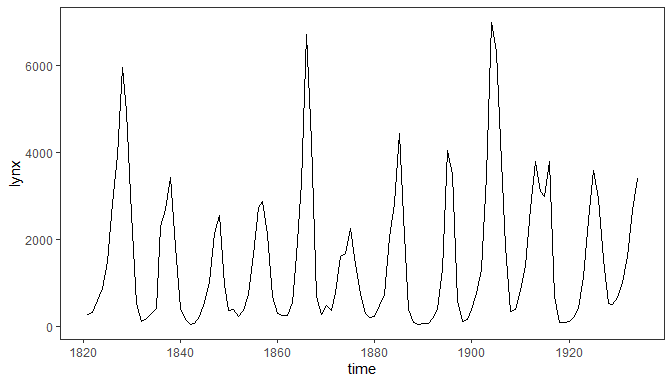

```r
ggplot(lynx, as.numeric = FALSE) + geom_line()
```

## Geometries

Three of the geometries described below allow the addition of plot layers containing insets. Insets can be plots, tables, bitmaps, or grid objects. Insets can be also added as annotations. Using for `data` a tibble with a list column containing data frames or tibbles allows like any other geom, the use of grouping, multiple insets per panel, faceting with different tables per panel, and different number of insets in each panel, i.e., individual tables added to a plot with `geom_table` behave similarly to individual `character` values added with `geom_text`.

Other geometries also described in this section support the use of native plot coordinates for positioning elements in the plotting area. Obviously these geometries are not meant to be used to display data, but instead they make it possible to add annotations to plots consistently across data sets even when using scales with varying limits.

Geometries defined in package ‘ggpp’

| Geometry | Main use | Aesthetics | Segment |
| --- | --- | --- | --- |
| `geom_text_s()` | data labels | x, y, label, size, family, font face, colour, alpha, group, angle, vjust, hjust | yes |
| `geom_label_s()` | data labels | x, y, label, size, family, font face, colour, fill, alpha, linewidth, linetype, group, vjust, hjust | yes |
| `geom_text_pairwise()` | data labels | x, xmin, xmax, y, label, size, family, font face, colour, alpha, group, angle, vjust, hjust | horiz. |
| `geom_label_pairwise()` | data labels | x, xmin, xmax, y, label, size, family, font face, colour, fill, alpha, linewidth, linetype, group, vjust, hjust | horiz. |
| `geom_text_npc()` | annotations | npcx, npcy, label, size, family, font face, colour, alpha, group, angle, vjust, hjust | no |
| `geom_label_npc()` | annotations | npcx, npcy, label, size, family, font face, colour, fill, alpha, linewidth, linetype, group, vjust, hjust | no |
| `geom_point_s()` | data labels | x, y, size, colour, fill, alpha, shape, stroke, group | yes |
| `geom_table()` | data labels | x, y, label, size, family, font face, colour, alpha, group, angle, vjust, hjust | yes |
| `geom_table_npc()` | annotations | npcx, npcy, label, size, family, font face, colour, alpha, group, angle, vjust, hjust | no |
| `geom_plot()` , `geom_grob()` | data labels | x, y, label, group, angle, vjust, hjust | yes |
| `geom_plot_npc()` , `geom_grob_npc()` | annotations | npcx, npcy, label, group, vjust, hjust | no |
| `geom_margin_arrow()` | data labels, scale labels, data | xintercept, yintercept, label, size, family, font face, colour, alpha, group, vjust, hjust | no |
| `geom_margin_point()` | data labels, scale labels, data | xintercept, yintercept, label, size, family, font face, colour, alpha, group, vjust, hjust | no |
| `geom_margin_grob()` | data labels, scale labels, data | xintercept, yintercept, label, size, family, font face, colour, alpha, group, vjust, hjust | no |
| `geom_quadrant_lines()` , `geom_vhlines()` | data labels, scale labels, data | xintercept, yintercept, label, size, family, font face, colour, alpha, group, vjust, hjust | no |

### geom_table() and stat_fmt_table()

The *geometry* `geom_table()` plots a data frame or tibble, nested in a tibble passed as data argument, using *aesthetics* `x` and `y` for positioning, and `label` for the list of data frames containing the data for the tables. The tables are created as ‘grid’ grobs and added as usual to the ggplot object. In contrast to “standard” geoms, this geom by default does not inherit the globally mapped aesthetics. Tables are always added at their native sizes, which can be altered by changing the `size` of the text in them.

Passing a data frame or a tibble results in the same plot, but there is a difference in how a `list` is added as a column to them, as shown below.

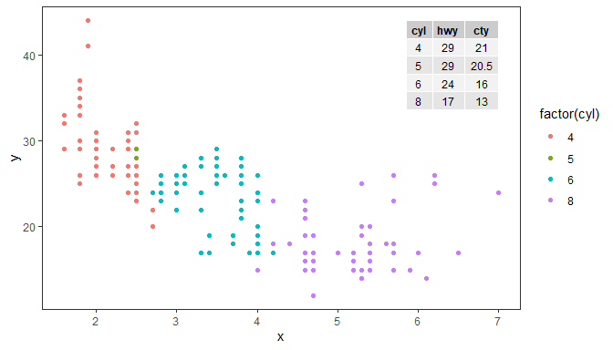

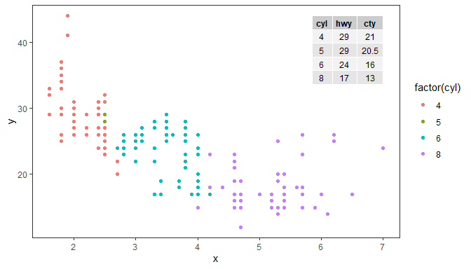

```r
tb <- mpg %>%
  group_by(cyl) %>%
  summarise(hwy = median(hwy), cty = median(cty))

# using R's data frames we need to call I() to add the list as is
data.df <- data.frame(x = 7, y = 44, tb = I(list(tb)))

ggplot(mpg, aes(displ, hwy, colour = factor(cyl))) +
  geom_table(data = data.df, aes(x, y, label = tb)) +
  geom_point()

# using 'tibble' the list is added as is by default
data.tb <- tibble(x = 7, y = 44, tb = list(tb))

ggplot(mpg, aes(displ, hwy, colour = factor(cyl))) +
  geom_table(data = data.tb, aes(x, y, label = tb)) +
  geom_point()
```

In plots with a single panel it can be easier to use `annotate()` to add inset tables, here creating the same plot as above. When using `annotate()` single data frames, ggplots or grobs do not need to be wrapped in a list, although lists are also supported.

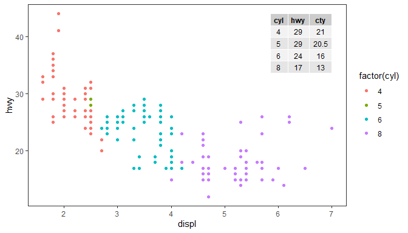

```r
tb <- mpg %>%
  group_by(cyl) %>%
  summarise(hwy = median(hwy), cty = median(cty))

ggplot(mpg, aes(displ, hwy, colour = factor(cyl))) +
  annotate("table", x = 7, y = 44, label = tb) +
  geom_point()
```

Table themes are supported through parameter `table.theme` and if variables or constants are mapped to the `colour`, `fill`, `size`, `alpha` or `family` aesthetics they override the corresponding default theme settings. The display of `rownames` and `colnames` can be enabled or disable through parameter `table.rownames` and `table.colnames` and the horizontal justification of text in the core of the table through parameter `table.hjust`.

Parameter `table.theme` accepts as arguments `NULL` for use of the the default as set at time of rendering, a `ttheme` constructor function such as those defined in package ‘gridExtra’, or the variations on them defined in package ‘ggpp’. The active default can be set with function `ttheme_set()`.

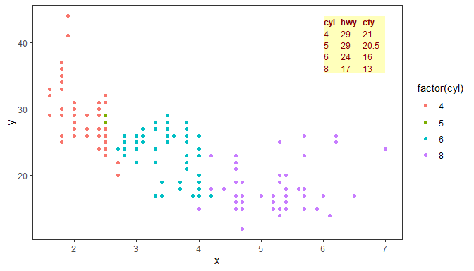

```r
ggplot(mpg, aes(displ, hwy, colour = factor(cyl))) +
  geom_table(data = data.tb, aes(x, y, label = tb),
             table.theme = ttheme_gtsimple,
             table.hjust = 0, colour = "darkred", fill = "#FFFFBB") +
  geom_point()
```

Transparency can be set with the `alpha`aesthetic or in the table theme.

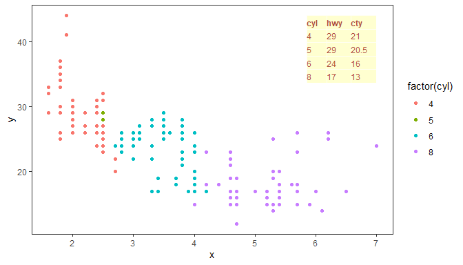

```r
ggplot(mpg, aes(displ, hwy, colour = factor(cyl))) +
  geom_table(data = data.tb, aes(x, y, label = tb),
             table.theme = ttheme_gtdefault,
             table.hjust = 0,
             colour = "darkred", fill = "#FFFFBB",
             alpha = 0.7) +
  geom_point()
```

Using `stat_fmt_tb()` we can rename columns and rows of the tibble, reorder them and/or select a subset of columns or rows as shown below. To provide a complete example we also replace the names of the scales for *x*, *y* and *color* aesthetics. Here we pass a `character` vector with the original names of the columns in full, but partial matching is tried when needed. It is also possible to use a `numeric` vector of positional indexes.

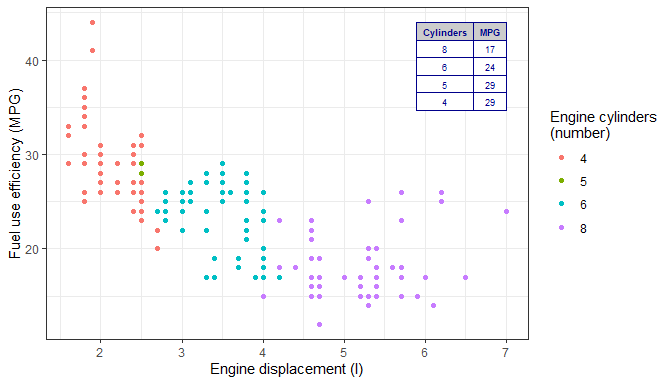

```r
ggplot(mpg, aes(displ, hwy, colour = factor(cyl))) +
  geom_table(data = data.tb, aes(x, y, label = tb),
             table.theme = ttheme_gtlight,
             size = 3, colour = "darkblue",
             stat = "fmt_tb",
             tb.vars = c(Cylinders = "cyl", MPG = "hwy"), # rename
             tb.rows = 4:1) + # change order
  labs(x = "Engine displacement (l)", y = "Fuel use efficiency (MPG)",
       colour = "Engine cylinders\n(number)") +
  geom_point() +
  theme_bw()
```

Parsed text, using plot math syntax is supported in the table, with fall-back to plain text in case of parsing errors, on a cell by cell basis (see `tableGrob()` in package ‘gridExtra’ for details, as this function is used to build the table). Here we plot the MPG for city traffic and we can see that the plotting area expands to include the coordinates at which the table is anchored. Justification is by default set to `"inward"` which ensures that the table is fully within the plotting region.

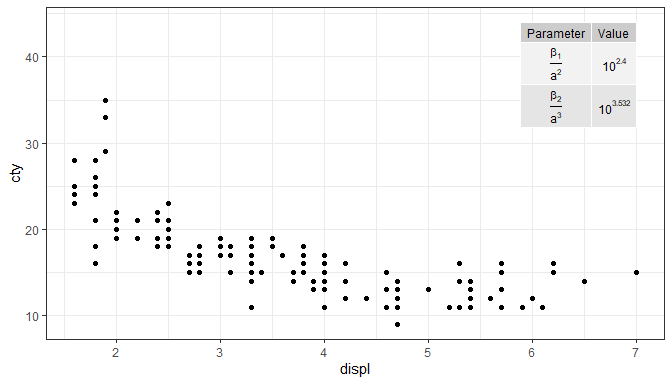

```r
tb.pm <- tibble(Parameter = c("frac(beta[1], a^2)", "frac(beta[2], a^3)"),
                Value = c("10^2.4", "10^3.532"))
data.tb <- tibble(x = 7, y = 44, tb = list(tb.pm))
ggplot(mpg, aes(displ, cty)) +
  geom_point() +
  geom_table(data = data.tb, aes(x, y, label = tb), parse = TRUE) +
  theme_bw()
```

As implemented, there is no limitation to the number of insets, and faceting is respected. If the base plot shows a map, multiple small tables could be superimposed on different countries or regions. The size of the table inset is given by the *size* aesthetic, so like for `geom_text()` it is independent of the `ggplot2::theme()` and controlled by the `table.theme` directly or indirectly through the *size* aesthetic.

Please see section **Normalised Parent Coordinates** below for a description of `geom_table_npc()`.

### geom_plot()

The `geom_plot()` *geometry* plots ggplot objects, nested in a tibble passed as data argument, using *aesthetics* `x` and `y` for positioning, and `label` for the ggplot object containing the definition of the plot to be nested. With this approach in plots with facets the insets can be different in each panel. It is also possible to inset more than one plot in a single call simply by creating a tibble with multiple rows.

Behind the scenes, one Grob is created for each plot to be inset. The conversion is done with `ggplotGrob()` and the Grobs added to the main ggplot object.

As an example we produce a plot where the inset plot is a zoomed-in detail from the main plot. In this case the main and inset plots start as the same plot. In most cases the size of text and other elements in the inset should be smaller than in the main plot. Here we override the default theme setting the `base_size` from its default of 11 pt to 8 pt.

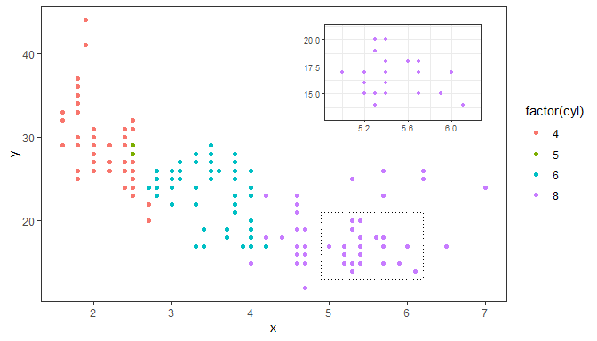

```r
p <- ggplot(mpg, aes(displ, hwy, colour = factor(cyl))) +
  geom_point()

data.tb <-
  tibble(x = 7, y = 44,
         plot = list(p +
                       coord_cartesian(xlim = c(4.9, 6.2),
                                       ylim = c(13, 21)) +
                       labs(x = NULL, y = NULL) +
                       theme_bw(8) +
                       scale_colour_discrete(guide = "none")))

ggplot(mpg, aes(displ, hwy, colour = factor(cyl))) +
  geom_plot(data = data.tb, aes(x, y, label = plot)) +
  annotate(geom = "rect",
           xmin = 4.9, xmax = 6.2, ymin = 13, ymax = 21,
           linetype = "dotted", fill = NA, colour = "black") +
  geom_point()
```

In general, the inset plot can be any ggplot object, allowing the creation of very different combinations of main plot and inset plots. Here we use the inset to show summaries as in the previous example of an inset table.

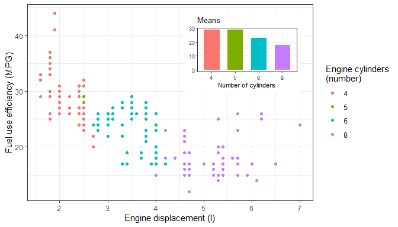

```r
p <- ggplot(mpg, aes(factor(cyl), hwy, fill = factor(cyl))) +
  stat_summary(geom = "col", fun = mean, width = 2/3) +
  labs(x = "Number of cylinders", y = NULL, title = "Means") +
  scale_fill_discrete(guide = "none")

data.tb <- tibble(x = 7, y = 44,
                  plot = list(p +
                                theme_bw(8)))

ggplot(mpg, aes(displ, hwy, colour = factor(cyl))) +
  geom_plot(data = data.tb, aes(x, y, label = plot)) +
  geom_point() +
  labs(x = "Engine displacement (l)", y = "Fuel use efficiency (MPG)",
       colour = "Engine cylinders\n(number)") +
  theme_bw()
```

The same plot as above can be created using `annotate()`, but be aware that when using facets, ‘ggplot2’ annotations are identical in all panels.

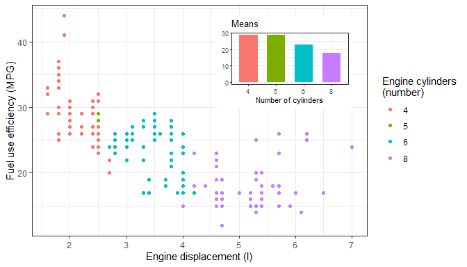

```r
p <- ggplot(mpg, aes(factor(cyl), hwy, fill = factor(cyl))) +
  stat_summary(geom = "col", fun = mean, width = 2/3) +
  labs(x = "Number of cylinders", y = NULL, title = "Means") +
  scale_fill_discrete(guide = "none")

ggplot(mpg, aes(displ, hwy, colour = factor(cyl))) +
  annotate("plot", x = 7, y = 44, label = p + theme_bw(8)) +
  geom_point() +
  labs(x = "Engine displacement (l)", y = "Fuel use efficiency (MPG)",
       colour = "Engine cylinders\n(number)") +
  theme_bw()
```

As implemented in ‘ggpp’ geometries, there is no limitation to the number of insets, and faceting is respected. If the base plot shows a map or a bitmap, multiple small plots could be superimposed on different countries or regions. The size of the insets is controlled by the `vp.width` and `vp.height` aesthetics as a fraction of the main plot’s plotting region. Consequently, the insets are scaled together with the main plot. A possible unintuitive but useful feature, is that the theme is linked to each plot.

Please see section **Normalised Parent Coordinates** below for a description of `geom_plot_npc()`.

### geom_grob()

The `geom_grob()` *geometry* plots grobs (graphical objects as created with package ‘grid’), nested in a tibble passed as data argument, using *aesthetics* `x` and `y` for positioning, and `label` for the Grob object. While `geom_table()` and `geom_plot()` take as values mapped to the `label` aesthetics tibbles or data frames, and ggplots, respectively, and convert them into Grobs, `geom_grob()` expects Grobs ready to be rendered. This means that any Grob created using ‘grid’ or its extensions can be added as a data label to a ggplot.

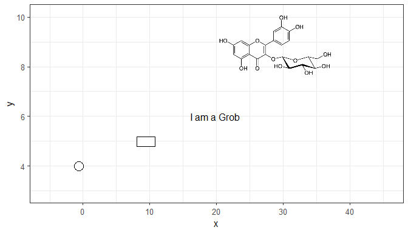

```r
file.name <-
  system.file("extdata", "Isoquercitin.png",
              package = "ggpp", mustWork = TRUE)
Isoquercitin <- magick::image_read(file.name)
grobs.tb <- tibble(x = c(0, 10, 20, 40), y = c(4, 5, 6, 9),
                   width = c(0.05, 0.05, 0.01, 1),
                   height =  c(0.05, 0.05, 0.01, 0.3),
                   grob = list(grid::circleGrob(),
                               grid::rectGrob(),
                               grid::textGrob("I am a Grob"),
                               grid::rasterGrob(image = Isoquercitin)))

ggplot() +
  geom_grob(data = grobs.tb,
            aes(x, y, label = grob, vp.width = width, vp.height = height),
            hjust = 0.7, vjust = 0.55) +
  scale_y_continuous(expand = expansion(mult = 0.3, add = 0)) +
  scale_x_continuous(expand = expansion(mult = 0.2, add = 0)) +
  theme_bw(12)
```

As shown above for inset tables and inset plots, it is also possible to use `annotate()` with Grobs. The next example insets a single `Grob`. Here we reuse the bitmap `Isoquercitin` read in the previous example. The Grob is contained in a viewport. Here setting `width = 1` (“npc” units) when creating the `Grob` from the bitmap ensures that the bitmap fills the width of the viewport (to ensure that the inset is not distorted, set only one of `width` or `height`). The argument to `vp.width` or `vp.height`, also in “npc” units, determines the size of the `Grob` relative to the size of the plotting area.

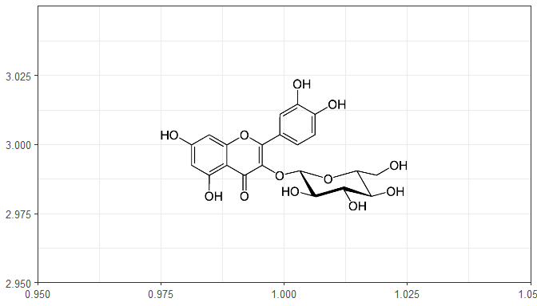

```r
ggplot() +
  annotate("grob", x = 1, y = 3, vp.width = 0.5,
           label = grid::rasterGrob(image = Isoquercitin, width = 1)) +
  theme_bw(12)
```

`geom_grob()` is designed thinking that its main use will be for graphical annotations, although one could use it for infographics with multiple copies of each grob, this would go against the grammar of graphics. In this implementation grobs cannot be mapped to an aesthetic through a scale.

As implemented, there is no limitation to the number of insets and faceting is respected. If the base plot shows a map or a bitmap, multiple simple grobs (e.g. national flags) could be superimposed on different countries. The size of the insets is controlled by the `vp.width` and `vp.height` aesthetics as a fraction of the main plot’s plotting region. Consequently, the insets are scaled together with the main plot.

Please see section **Normalised Parent Coordinates** below for a description of `geom_grob_npc()`.

### geom_vhlines()

This is a convenience geometry that adds both vertical and horizontal guide lines on the same plot layer, using the same syntax as `geom_hline()` and `geom_vline()` from package ‘ggplot2’.

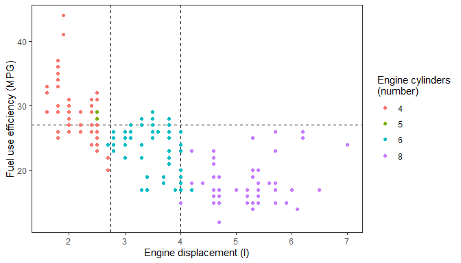

```r
ggplot(mpg, aes(displ, hwy, colour = factor(cyl))) +
  geom_vhlines(xintercept = c(2.75, 4), yintercept = 27, linetype = "dashed") +
  geom_point() +
  labs(x = "Engine displacement (l)", y = "Fuel use efficiency (MPG)",
       colour = "Engine cylinders\n(number)")
```

### geom_text_s(), geom_label_s(), and geom_point_s()

With package ‘ggrepel’ we have become used to easily add data labels linked to the observations or points by a line segment or arrow. However, sometimes a plot has few text labels and repulsion is unnecessary. In such cases nudging or dodging may be enough, or even preferable so as to achieve consistent positions irrespective of plot scaling or graphic device used for rendering.

We can achieve this with `geom_text_s()` (formerly named `geom_text_linked()`) or `geom_label_s()`, together with a suitable position function that retains the original *x* and *y* coordinates of the point. We provide several different position functions described in a later section, all of which retain the initial position in `data$x_orig` and `data_$y_orig`. Function `position_nudge_keep()` is used by default providing the same default behaviour as `geom_text()` and `geom_label()` from ‘ggplot2’. However, when nudging using the `nudeg_x` and/or `nudeg_y` parameters, or passing as argument to `position` a position function that keeps the original position, by default linking segments are drawn between the original and nudged or displaced positions. Passing `add.segments = FALSE` disables the drawing of segments. The equivalent geometry for points connected by segments to their original positions is `geom_point_s()`.

These geometries do not use like those in package ‘ggrepel’ special aesthetics to set the properties of segments. These geometries allow the user to select to which graphic elements to apply the mapped aesthetics. In addition `geom_label_s()` adds support for `linewidth` and `linetype` aesthetics for the box.

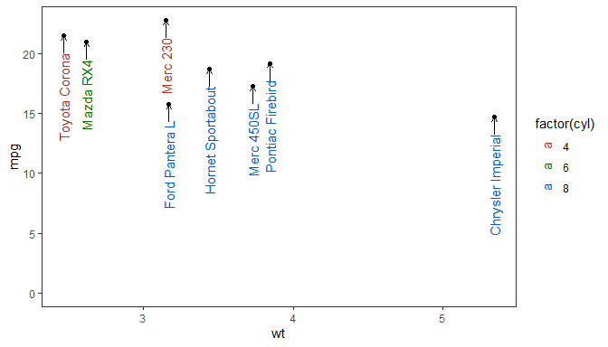

```r
my.cars <- mtcars[c(TRUE, FALSE, FALSE, FALSE), ]
my.cars$name <- rownames(my.cars)
my.cars <- my.cars[order(my.cars$wt), ]
ggplot(my.cars, aes(wt, mpg, label = name)) +
  geom_point() +
  geom_text_s(aes(colour = factor(cyl)),
              vjust = 0.5,
              angle = 90,
              nudge_y = -1.5,
              arrow = arrow(length = grid::unit(1.5, "mm"))) +
  scale_colour_discrete(l = 40) +
  expand_limits(y = 0)
```

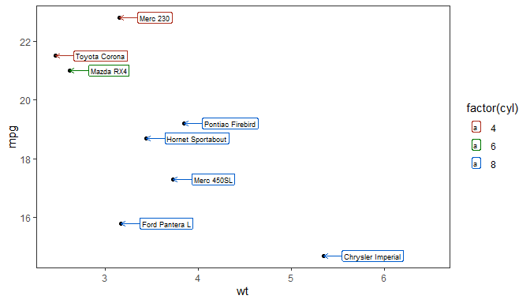

```r
my.cars <- mtcars[c(TRUE, FALSE, FALSE, FALSE), ]
my.cars$name <- rownames(my.cars)
my.cars <- my.cars[order(my.cars$wt), ]
ggplot(my.cars, aes(wt, mpg, label = name)) +
  geom_point() +
  geom_label_s(aes(colour = factor(cyl)),
               size = 2.5,
               linewidth = 0.5,
               colour.target = c("box", "segment"),
               nudge_x = 0.2,
               arrow = arrow(length = grid::unit(1.5, "mm"))) +
  scale_colour_discrete(l = 40) +
  expand_limits(x = 6.5)
```

### geom_text_pairwise() and geom_label_pairwise()

When labels show the results of pairwise comparisons, it is natural to use a segment to connect the members of the pairs compared to a textual label.

```r
# With a factor mapped to x, highlight pairs

my.cars <- mtcars
my.cars$name <- rownames(my.cars)
p1 <- ggplot(my.cars, aes(factor(cyl), mpg)) +
       geom_boxplot(width = 0.33)
```

```r
my.pairs <-
  data.frame(A = 1:2, B = 2:3, bar.height = c(12, 30),
             p.value = c(0.01, 0.05678))
```

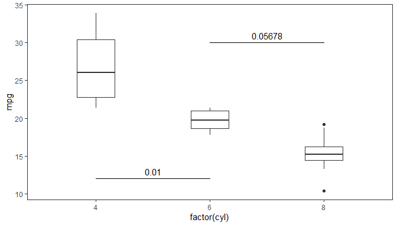

```r
p1 +
  geom_text_pairwise(data = my.pairs,
                     aes(xmin = A, xmax = B,
                         y = bar.height,
                         label = p.value),
                     parse = TRUE)
```

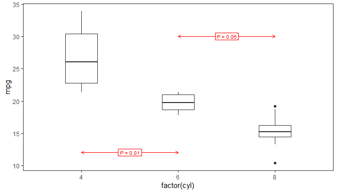

```r
p1 +
  geom_label_pairwise(data = my.pairs,
                      aes(xmin = A, xmax = B,
                          y = bar.height,
                          label = sprintf("italic(P)~`=`~%.2f", p.value)),
                      colour = "red", size = 2.75,
                      arrow = grid::arrow(angle = 30,
                                          length = unit(1.5, "mm"),
                                          ends = "both"),
                      parse = TRUE)
```

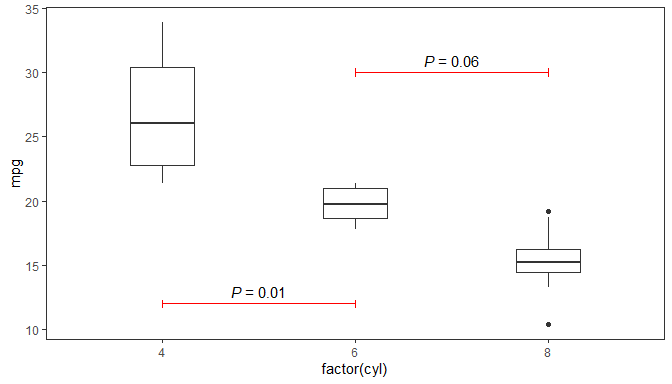

```r
p1 +
  geom_text_pairwise(data = my.pairs,
                     aes(xmin = A, xmax = B,
                         y = bar.height,
                         label = sprintf("italic(P)~`=`~%.2f", p.value)),
                     colour = "red", colour.target = "segment",
                     arrow = grid::arrow(angle = 90,
                                         length = unit(1, "mm"),
                                         ends = "both"),
                     parse = TRUE)
```

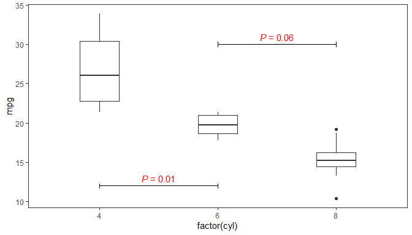

```r
p1 +
  geom_text_pairwise(data = my.pairs,
                     aes(xmin = A, xmax = B,
                         y = bar.height,
                         label = sprintf("italic(P)~`=`~%.2f", p.value)),
                     colour = "red", colour.target = "text",
                     arrow = grid::arrow(angle = 90,
                                         length = unit(1, "mm"),
                                         ends = "both"),
                     parse = TRUE)
```

Another situation where horizontal or vertical segments can be useful if to label ranges of values of a continuous variable.

```r
# with a numeric vector mapped to x, indicate range

p2 <-
  ggplot(my.cars, aes(disp, mpg)) +
    geom_point()

my.ranges <-
  data.frame(A = c(50, 400),
             B = c(200, 500),
             bar.height = 5,
             text = c("small", "large"))
```

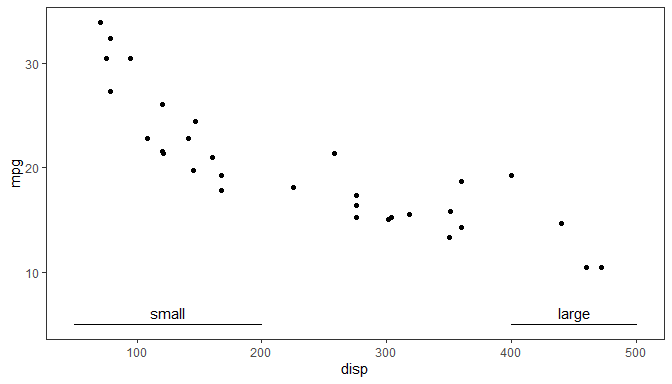

```r
p2 +
  geom_text_pairwise(data = my.ranges,
                     aes(xmin = A, xmax = B,
                     y = bar.height, label = text))
```

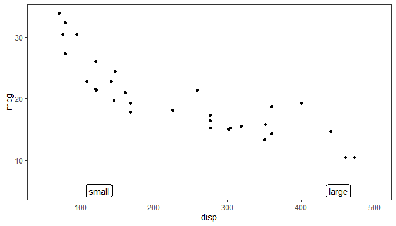

```r
p2 +
  geom_label_pairwise(data = my.ranges,
                      aes(xmin = A, xmax = B,
                          y = bar.height, label = text))
```

### Normalised Parent Coordinates

R’s ‘grid’ package defines several units that can be used to describe the locations of plot elements. In ‘ggplot2’ the *x* and *y* aesthetics are directly mapped to `"native"` or data units. For consistent location of **annotations** with respect to the plotting area we need to rely on `"npc"` which are expressed relative to the size of the grid viewport. The plotting area in a ggplot is implemented as a ‘grid’ viewport and support for `"npc"` coordinates is relatively easy to implement.

To support `"npc"` positions we have implemented *scales* for two new (pseudo) *aesthetics*, `npcx` and `npcy`. These are very simple continuous scales which do not support any transformation or changes to their limits, both of which would be meaningless for `"npc"` units. Variables mapped to these aesthetics can be either numerical with values in the range zero to one or character. A limited set of strings are recognised and converted to `"npc"` units: `"bottom"`, `"center"`, `"top"`, `"left"`, `"middle"`, `"right"` (`"centre"` is a synonym for `"center"`).

To make these scales useful we need also to define *geometries* that use these new aesthetics. Package ‘ggpp’ currently provides `geom_text_npc()`, `geom_label_npc()`, `geom_table_npc()`, `geom_plot_npc()` and `geom_grob_npc()`.

As is the case for `geom_text()` and `geom_label()` from package ‘ggplot2’, `"bottom"`, `"center"`, `"top"`, `"left"`, `"middle"`, `"right"`, plus `"inward"` and `"outward"` can be used, as well as numeric values, to control the justification. Justification defaults to `"inward"` in the geometries described here.

While the usual *x* and *y* aesthetics are used whenever the positions of plot elements represent data values, these new scales and geometries are useful only for annotations, i.e., in those cases when we want plot elements at specific positions within the plotting area irrespective of the ranges of the data mapped to the *x* and *y* aesthetics. When writing scripts or functions that may be applied to different data sets these new *aesthetics* help by keeping the code concise and reusable. These *geometries* are used by default by several of the statistics described in later sections and those defined in package ‘ggpmisc’.

As an example let’s imagine that we want to add the structure of a metabolite to a plot. Its position has nothing to do with the data mapped to *x* and *y*, so it is conceptually better to use `"npc"` coordinates. The big practical advantage is that this also allows to keep this part of the plot definition independent of the data being plotted, giving a major advantage in the case of plots with facets with free scale limits. This example can be easily adapted to `geom_plot_npc()` where a list of ggplots is mapped to `label`, and to `geom_table_npc()` where a list of data frame is mapped to `label`.

We produce the example plot by first constructing a tibble to contain the grob and the coordinate data, and then map these variables to aesthetics using `aes()`. In the example the tibble has a single row, but this is not a requirement. In this respect these geoms behave as normal geoms, with facets also supported.

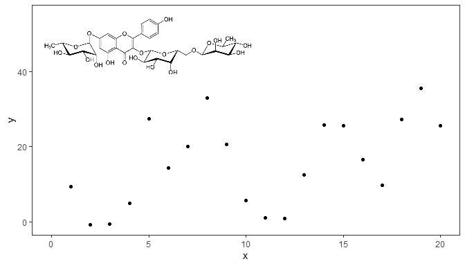

```r
file.name <-
  system.file("extdata", "Robinin.png",
              package = "ggpp", mustWork = TRUE)
Robinin <- magick::image_read(file.name)

set.seed(123456)
data.tb <- tibble(x = 1:20, y = (1:20) + rnorm(20, 0, 10))

flavo.tb <- tibble(x = 0.02,
                   y = 0.95,
                   width = 1/2,
                   height = 1/4,
                   grob = list(grid::rasterGrob(image = Robinin)))

ggplot(data.tb, aes(x, y)) +
  geom_grob_npc(data = flavo.tb,
                aes(label = grob, npcx = x, npcy = y,
                    vp.width = width, vp.height = height)) +
  geom_point() +
  expand_limits(y = 55, x = 0)
```

Alternatively, we can pass constant values to `geom_grob_npc()` to obtain the same plot. This approach can be handy in simple cases.

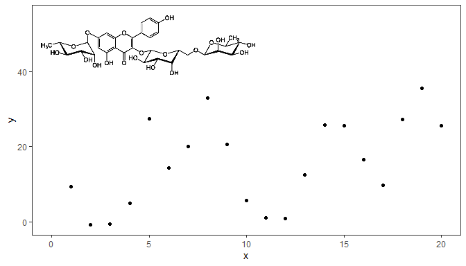

```r
ggplot(data.tb, aes(x, y)) +
  geom_grob_npc(label = list(grid::rasterGrob(image = Robinin, width = 1)),
                npcx = 0.02, npcy = 0.95,
                vp.width = 1/2, vp.height = 1/4) +
  geom_point() +
  expand_limits(y = 55, x = 0)
```

We can also use `annotate()` if the annotation should be the same for all panels, or if we have a single figure panel. In this case there is no need to wrap a single `grob` in a list.

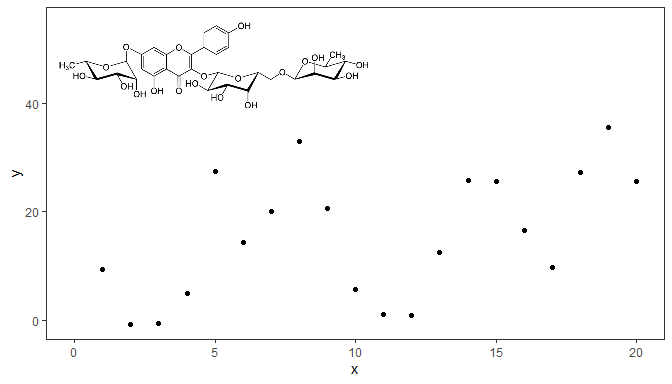

```r
ggplot(data.tb, aes(x, y)) +
  annotate("grob_npc", label = grid::rasterGrob(image = Robinin, width = 1),
                npcx = 0.02, npcy = 0.95, vp.width = 1/2, vp.height = 1/4) +
  geom_point() +
  expand_limits(y = 55, x = 0)
```

Two additional geometries are based on existing ‘ggplot2’ geometries. They are based on `geom_text()` and `geom_label()`. We give an example using `geom_text_npc()` to produce a “classic” labelling for facets matching the style of `theme_classic()` and traditional scientific journals’ design.

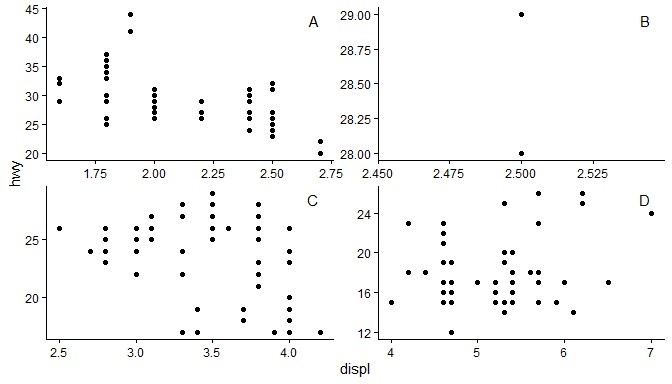

```r
corner_letters.tb <- tibble(label = LETTERS[1:4],
                            x = "right",
                            y = "top",
                            cyl = c(4,5,6,8))
ggplot(mpg, aes(displ, hwy)) +
  geom_point() +
  facet_wrap(~cyl, scales = "free") +
  geom_text_npc(data = corner_letters.tb,
                aes(npcx = x, npcy = y, label = label)) +
  theme_classic() +
  theme(strip.background = element_blank(),
        strip.text.x = element_blank())
```

### Marginal markings

‘ggplot2’ provides `geom_rug()`, `geom_vline()` and `geom_hline()`. Rug plots are intended to be used to represent distributions along the margins of plot. `geom_vline()` and `geom_hline()`are normally used to separate regions in a plot or to highlight important values along the *x* or *y* axis. When creating plots it is sometimes useful to put small marks along the axes, just inside the plotting area, similar to those in a rug plot, but like `geom_vline()` and `geom_hline()` in their purpose.

Three *geometries* provide such markers: `geom_margin_point()`, `geom_margin_arrow()`, and `geom_margin_grob()`. They behave similarly to `geom_vline()` and `geom_hline()` and their positions are determined also by the `xintercept` and `yintercept` aesthetics.

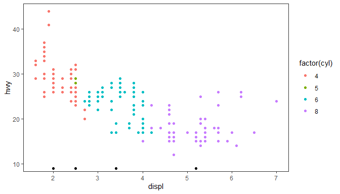

```r
data.tb <- mpg %>%
  group_by(cyl) %>%
  summarise(hwy = median(hwy), displ = median(displ))
ggplot(mpg, aes(displ, hwy, colour = factor(cyl))) +
  geom_x_margin_point(data = data.tb,
                      aes(xintercept = displ, fill = factor(cyl))) +
  expand_limits(y = 10) +
  geom_point()
```

## Statistics

Statistics defined in package ‘ggpp’.

| Statistic | Main use | Usual geometries | Most used with | Compute function |
| --- | --- | --- | --- | --- |
| `stat_fmt_tb()` | formatting and selection | `geom_table()` | tables as data labels | group |
| `stat_fmt_tb()` | formatting and selection | `geom_table_npc()` | tables as annotations | group |
| `stat_dens2d_filter()` | local 2D density filtering | `geom_text_s()`, `geom_label_s()`, `geom_text()`, `geom_label()` | text as data labels | panel |
| `stat_dens2d_label()` | local 2D density filtering | `geom_text_repel()`, `geom_label_repel()` | text as data labels | panel |
| `stat_dens1d_filter()` | local 1D density filtering | `geom_text_s()`, `geom_label_s()`, `geom_text()`, `geom_label()` | text as data labels | panel |
| `stat_dens1d_label()` | local 1D density filtering | `geom_text_repel()`, `geom_label_repel()` | text as data labels | panel |
| `stat_dens2d_filter_g()` | local 2D density filtering | `geom_text_s()`, `geom_label_s()`, `geom_text()`, `geom_label()` | text as data labels | group |
| `stat_dens2d_label_g()` | local 2D density filtering | `geom_text_repel()`, `geom_label_repel()` | text as data labels | group |
| `stat_dens1d_filter_g()` | local 1D density filtering | `geom_text_s()`, `geom_label_s()`, `geom_text()`, `geom_label()` | text as data labels | group |
| `stat_dens1d_label_g()` | local 1D density filtering | `geom_text_repel()`, `geom_label_repel()` | data labels | group |
| `stat_panel_counts()` | number of observations | `geom_text()`, `geom_label()` | text as annotation | panel |
| `stat_group_counts()` | number of observations | `geom_text()`, `geom_label()` | text as annotation | panel |
| `stat_quadrant_counts()` | number of observations | `geom_text()`, `geom_label()` | text as annotation | panel |
| `stat_apply_panel()` | cummulative summaries | `geom_point()`, `geom_line()`, etc. | scatter and line plots | panel |
| `stat_apply_group()` | cummulative summaries | `geom_point()`, `geom_line()`, etc. | scatter and line plots | group |
| `stat_centroid()` | joint x and y summaries | `geom_point()`, `geom_rug()`, `geom_margin_arrow()`, etc. | data summary | group |
| `stat_summary_xy()` | joint x and y summaries | `geom_point()`, `geom_rug()`, `geom_margin_arrow()`, etc. | data summary | group |
| `stat_functions()` | compute y from x range | `geom_line()`, `geom_point()`, etc. | draw function curves | group |

### stat_centroid()

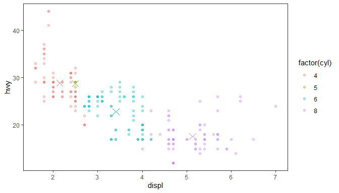

```r
ggplot(mpg, aes(displ, hwy, colour = factor(cyl))) +
  geom_point(alpha = 0.33) +
  stat_centroid(shape = "cross", size = 4)
```

Other functions can be passed to this statistic as long as they return a single value that can be mapped to the `x` and `y` aesthetics (numeric, time or a factor).

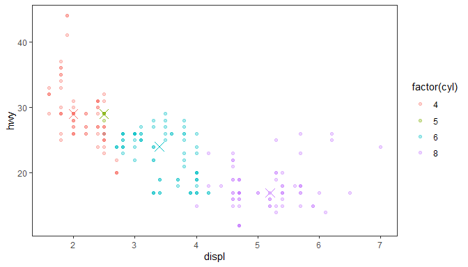

```r
ggplot(mpg, aes(displ, hwy, colour = factor(cyl))) +
  geom_point(alpha = 0.33) +
  stat_centroid(shape = "cross", size = 4, .fun = median)
```

The very similar `stat_summary_xy()` accepts different functions for `x` and `y`.

### stat_group_counts()

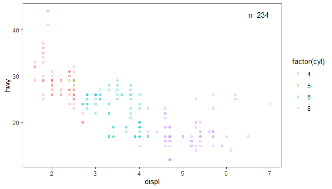

```r
ggplot(mpg, aes(displ, hwy, colour = factor(cyl))) +
  geom_point(alpha = 0.25) +
  stat_panel_counts()
```

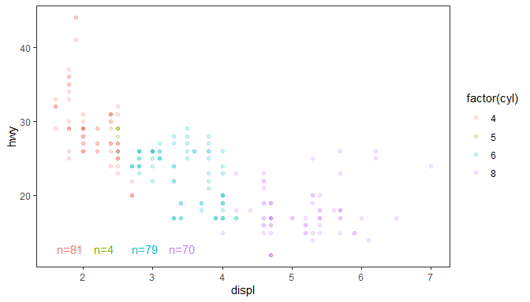

```r
ggplot(mpg, aes(displ, hwy, colour = factor(cyl))) +
  geom_point(alpha = 0.2) +
  stat_group_counts(hstep = 0.09, vstep = 0, label.x = "left", label.y = "bottom")
```

Labels with counts of observations can be also added when aesthetics `x` or `y` are factors, as in ggplots factors create a grouping. If the labels are to be aligned with the factor levels, we need to use a “normal” geometry such as `geom_text()` instead of the default `geom_text_npc()` and set the corresponding label positions to `"factor"`.

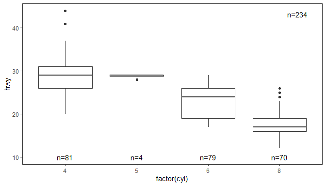

```r
ggplot(mpg,
       aes(factor(cyl), hwy)) +
  stat_boxplot() +
  stat_group_counts(geom = "text",
                    label.y = 10,
                    label.x = "factor") +
  stat_panel_counts()
```

### stat_quadrant_counts() and geom_quadrant_lines()

This statistic automates the annotation of plots with number of observations (counts, fractions, or percents), either by quadrant, by pairs of quadrants or the four quadrants taken together (whole plotting area). Its companion geometry, `geom_quadrant_lines()` is used in the examples to highlight the quadrants.

We generate some artificial data.

```r
set.seed(4321)
# generate artificial data
x <- -99:100
y <- x + rnorm(length(x), mean = 0, sd = abs(x))
my.data <- data.frame(x,
                      y,
                      group = c("A", "B"))
```

Using defaults except for color.

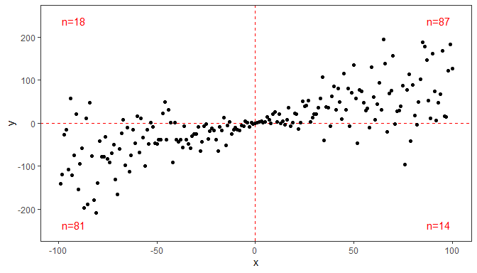

```r
ggplot(my.data, aes(x, y)) +
  geom_quadrant_lines(colour = "red") +
  stat_quadrant_counts(colour = "red") +
  geom_point() +
  expand_limits(y = c(-250, 250))
```

Number in quadrant over total observations.

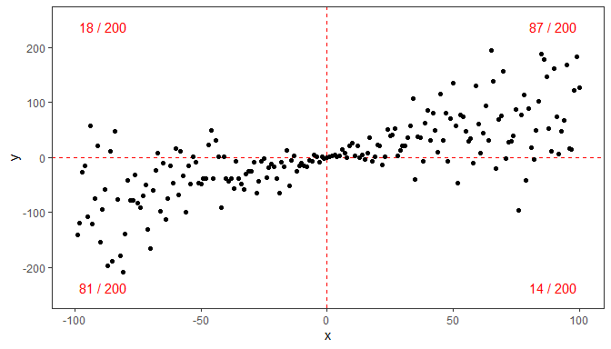

```r
ggplot(my.data, aes(x, y)) +
  geom_quadrant_lines(colour = "red") +
  stat_quadrant_counts(aes(label = after_stat(fr.label)), colour = "red") +
  geom_point() +
  expand_limits(y = c(-250, 250))
```

Decimal fractions.

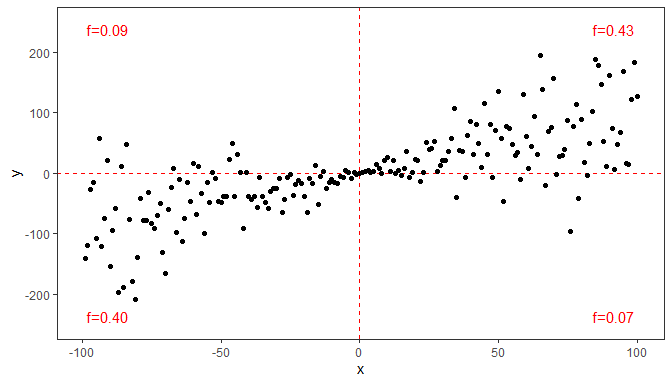

```r
ggplot(my.data, aes(x, y)) +
  geom_quadrant_lines(colour = "red") +
  stat_quadrant_counts(aes(label = after_stat(dec.label)), colour = "red") +
  geom_point() +
  expand_limits(y = c(-250, 250))
```

Percent of observations.

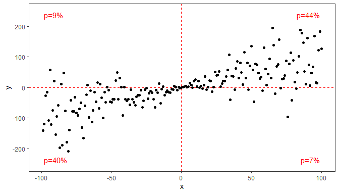

```r
ggplot(my.data, aes(x, y)) +
  geom_quadrant_lines(colour = "red") +
  stat_quadrant_counts(aes(label = after_stat(pc.label)), colour = "red") +
  geom_point() +
  expand_limits(y = c(-250, 250))
```

User-constructed labels.

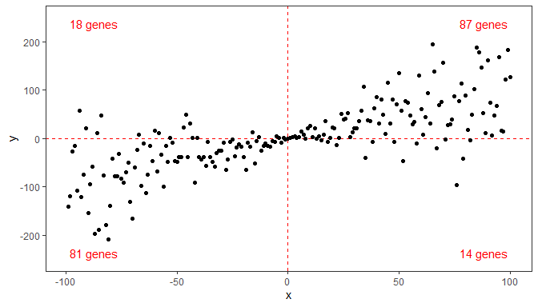

```r
ggplot(my.data, aes(x, y)) +
  geom_quadrant_lines(colour = "red") +
  stat_quadrant_counts(aes(label = sprintf("%i genes", after_stat(count))), colour = "red") +
  geom_point() +
  expand_limits(y = c(-250, 250))
```

Pooling quadrants along the *x*-axis. (`pool.along = "y"` pools along *y*.)

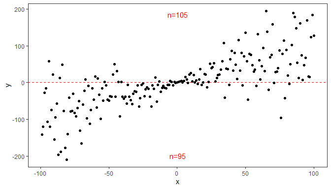

```r
ggplot(my.data, aes(x, y)) +
  geom_quadrant_lines(colour = "red", pool.along = "x") +
  stat_quadrant_counts(colour = "red", pool.along = "x") +
  geom_point()
```

Manual positioning of the text annotations and pooling of all four quadrants, and overriding the default formatting for the label.

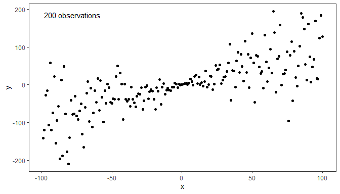

```r
ggplot(my.data, aes(x, y)) +
  geom_point() +
  stat_quadrant_counts(quadrants = 0L, label.x = "left",
                       aes(label = sprintf("%i observations", after_stat(count))))
```

Annotation of only specific quadrants.

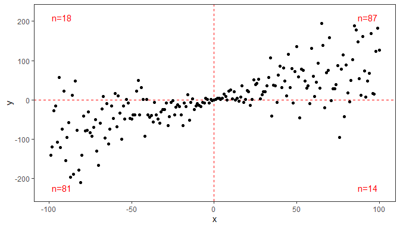

```r
ggplot(my.data, aes(x, y)) +
  geom_quadrant_lines(colour = "red") +
  stat_quadrant_counts(colour = "red", quadrants = c(1:4)) +
  scale_y_continuous(expand = expansion(mult = 0.12)) + # add space
  geom_point()
```

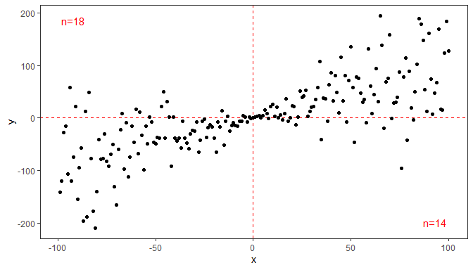

```r
ggplot(my.data, aes(x, y)) +
  geom_quadrant_lines(colour = "red") +
  stat_quadrant_counts(colour = "red", quadrants = c(2, 4)) +
  geom_point()
```

Using facets, even with free scale limits, the labels are placed consistently. This achieved by the default use of `geom_text_npc()` or as shown below by use of `geom_label_npc(). We expand the *y* limits to ensure that no observations are occluded by the labels.

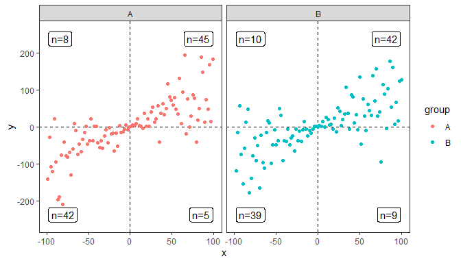

```r
ggplot(my.data, aes(x, y, colour = group)) +
  geom_quadrant_lines() +
  stat_quadrant_counts(geom = "label_npc") +
  geom_point() +
  expand_limits(y = c(-260, 260)) +
  facet_wrap(~group)
```

### stat_apply_group

This statistic applies functions to `x` and `y` data. The function(s) supplied as argument are expected to return a numeric vector. Both functions should return vectors of the same length. When possible it is usually better to apply functions through mappings using `aes()` when they are independent of grouping, or to use a transformation for the scale. However, when grouping is important, these statistics make it possible to avoid pre-computation of the data for a layer.

Here we plot the difference in trunk circumference between dates for each tree. (As the vector returned by `diff()` is one element shorter than its input, we delete the first value of `x` in `.fun.x`.).

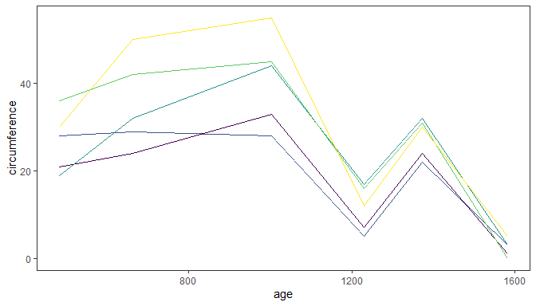

```r
ggplot(Orange, aes(age, circumference, colour = Tree)) +
  stat_apply_group(.fun.x = function(x) {x[-1L]},
                   .fun.y = diff)
```

### stat_dens2d_labels() and stat_dens2d_filter()

These stats had their origin in an enhancement suggestion for ‘ggrepel’ from Hadley Wickham and discussion with Kamil Slowikowski (ggrepel’s author) and others. In fact the code is based on code Kamil gave during the discussion, but simplified and taking a few additional ideas from `ggplot::stat_dens2d`.

**Warning!** Which observations are selected by the algorithm used, based on `MASS:kde2d`, depends strongly on the values of parameters `h` and `n`. You may need to alter the defaults by passing explicit arguments to these stats. Beware, though, that what are good values, may depend on individual data sets even if they include the same number of observations.

If we want to highlight the outermost observations at the edges of a empirical density distribution, values of `n` similar to those in the examples in the documentation of `MASS::kde2d` and `ggplot2::stat_dens2d` are suitable.

In contrast, if the aim is to prevent overlaps among labels, by preventing observation labeling in regions with *local* high density we need to fit a much more flexible surface based on a very dense grid of estimates. In this case, for the selection of observations to work cleanly, much larger values of `n` than in the examples in the documentation of `MASS::kde2d` and `ggplot2::stat_dens2d` are needed in most cases.

Functions `stat_dens2d_labels()` and `stat_dens2d_filter()` will return the density estimates if `return.density = TRUE` is passed when called. These density estimates can be plotted to visualize the density function being used to filter or reset the labels.

Some random data with random labels.

```r
random_string <- function(len = 3) {
paste(sample(letters, len, replace = TRUE), collapse = "")
}

# Make random data.
set.seed(1001)
d <- tibble::tibble(
  x = rnorm(100),
  y = rnorm(100),
  group = rep(c("A", "B"), c(50, 50)),
  lab = replicate(100, { random_string() })
)
```

The stat `stat_dens2d_filter` *filters* observations, in other words passes to the geom a subset of the data received as input. The default argument for `geom` is `"point"`.

Using defaults except for the color aesthetic. Highlight 1/4 of observations from lowest density areas of the whole plot panel (using the default of `pool.along = "xy"`) using overplotting of selected black points with red points. We also highlight the boundaries of the quadrants.

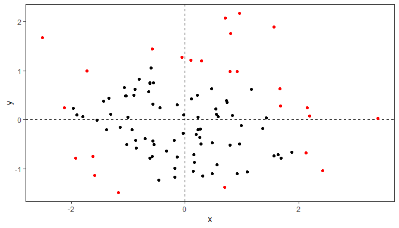

```r
ggplot(data = d, aes(x, y)) +
  geom_quadrant_lines(linetype = "dashed") +
  geom_point() +
  stat_dens2d_filter(keep.fraction = 1/4,
                     colour = "red")
```

Highlight 1/4 of observations from lowest density areas in each quadrant of the plot. We also highlight the boundaries of the quadrants. Compare the plot above to that below.

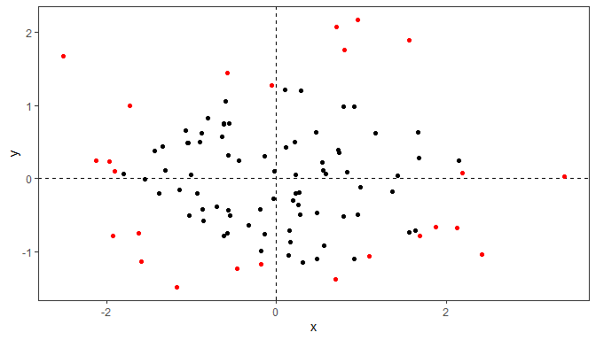

```r
ggplot(data = d, aes(x, y)) +
  geom_quadrant_lines(linetype = "dashed") +
  geom_point() +
  stat_dens2d_filter(keep.fraction = 1/4,
                     colour = "red",
                     pool.along = "none")
```

Highlight a given fraction of observations in each quadrant, by setting `pool.along = "none"`, and passing a vector of length four to `keep.fraction`.

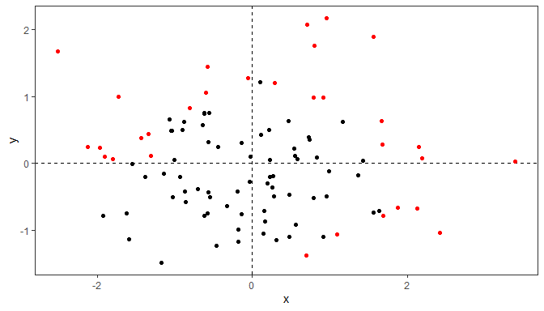

```r
ggplot(data = d, aes(x, y)) +
  geom_quadrant_lines(linetype = "dashed") +
  geom_point() +
  stat_dens2d_filter(keep.fraction = c(1/2, 1/4, 0, 1/2),
                     pool.along = "none",
                     colour = "red")
```

Keep always 20 observations by setting `keep.fraction = 1`.

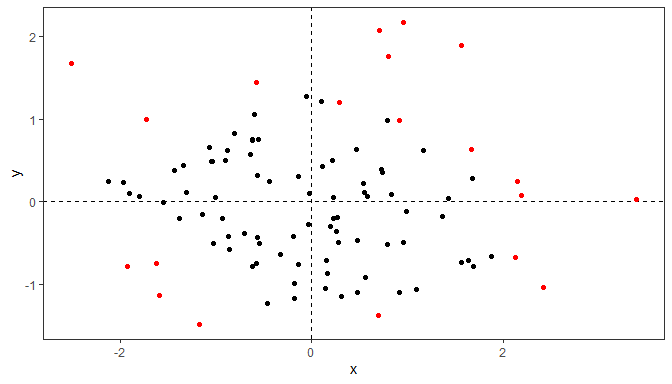

```r
ggplot(data = d, aes(x, y)) +
  geom_quadrant_lines(linetype = "dashed") +
  geom_point() +
  stat_dens2d_filter(keep.fraction = 1,
                     keep.number = 20,
                     colour = "red")
```

Keep always 20 observations, 5 per quadrant, by setting `pool.along = "none"`.

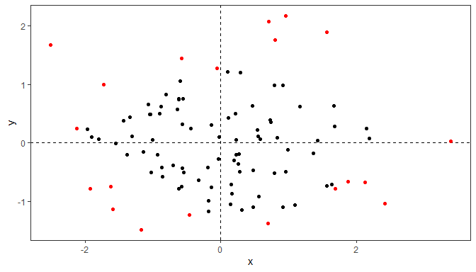

```r
ggplot(data = d, aes(x, y)) +
  geom_quadrant_lines(linetype = "dashed") +
  geom_point() +
  stat_dens2d_filter(keep.fraction = 1,
                     keep.number = 20,
                     pool.along = "none",
                     colour = "red")
```

Keep a given number of observations in each quadrant, by setting `pool.along = "none"`, and passing a vector of length four to `keep.number`.

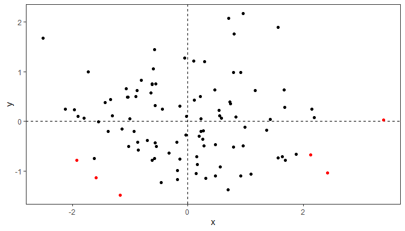

```r
ggplot(data = d, aes(x, y)) +
  geom_quadrant_lines(linetype = "dashed") +
  geom_point() +
  stat_dens2d_filter(keep.fraction = 1,
                     keep.number = c(1, 2, 3, 0),
                     pool.along = "none",
                     colour = "red")
```

A more elaborate example, 50% of observations, with color representing the local empirical density, only for them.

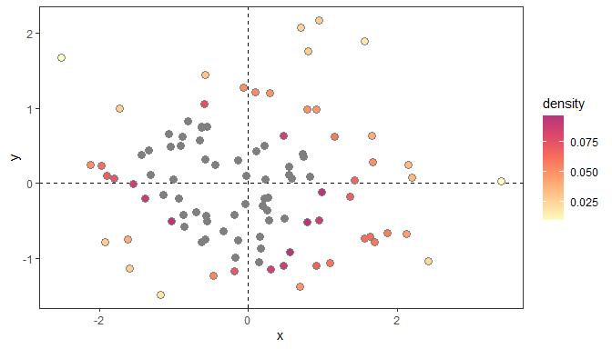

```r
ggplot(data = d, aes(x, y)) +
  geom_quadrant_lines(linetype = "dashed") +
  geom_point(size = 3, colour = "grey50") +
  stat_dens2d_filter(keep.fraction = 1/2,
                     return.density = TRUE,
                     aes(color = after_stat(density)),
                     size = 2,
                     show.legend = TRUE) +
  scale_color_viridis_c(direction = -1, option = "magma", begin = 0.5)
```

Highlighting 1/4 of the observations from the panel, using over-plotting with a ‘hollow’ shape. (We also shift one group with respect to the other in `data`, to show that grouping is ignored by `stat_dens2d_filter()`.

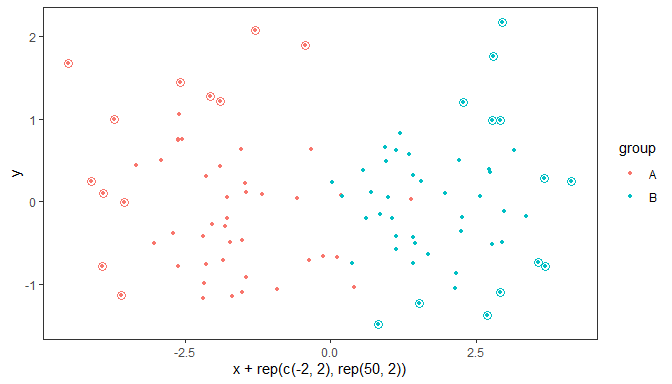

```r
ggplot(data = d, aes(x + rep(c(-2,2), rep(50,2)),
                     y,
                     colour = group)) +
   geom_point(size = 1) +
   stat_dens2d_filter(shape = 1, size = 3,
                      keep.fraction = 0.25)
```

Highlight 1/4 of observations from lowest density areas of the plot, with density assessed separately for each group. In this example grouping is based on the color aesthetic.

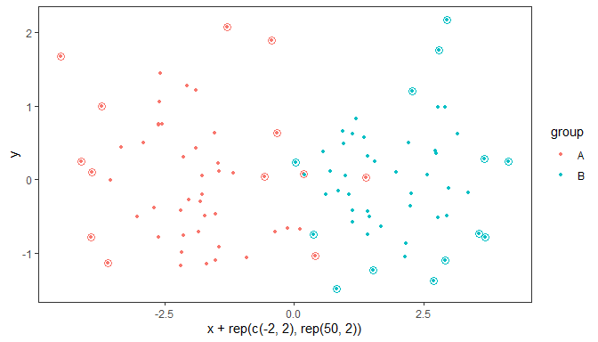

```r
ggplot(data = d, aes(x + rep(c(-2,2), rep(50,2)),
                     y,
                     colour = group)) +
   geom_point(size = 1) +
   stat_dens2d_filter_g(shape = 1,
                        size = 3,
                        keep.fraction = 0.25)
```

The stat `stat_dens2d_labels` *replaces* the values of the label (aesthetic) variable in `data` based on density of observations along the *x* or *y* axis in the plot panel. The replacement is given by the argument passed to `label.fill`, which can be a character string or a function accepting a character string as argument and returning also a character string.

The default value for `geom` is `"text"`. The default value of `label.fill` is `""` which results in empty labels, while using `NA` as fill label results in observations being omitted. Using `NA` as `label.fill` is similar to using `stat_dens2d_filter` as long as the geom used requires a `label` aesthetic.

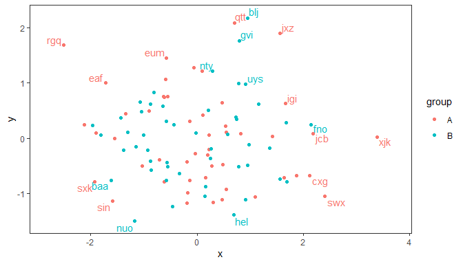

```r
ggplot(data = d, aes(x, y, label = lab, colour = group)) +
  geom_point() +
  stat_dens2d_labels(keep.fraction = 1/5,
                     position = position_nudge_center(x = 0.05,
                                                      y = 0.05,
                                                      center_x = 0,
                                                      center_y = 0),
                     vjust = "outward", hjust = "outward") +
  scale_x_continuous(expand = expansion(c(0.1, 0.1)))
```

Using the geoms from package ‘ggrepel’ avoids clashes among labels and clashes of labels with data points. Please, see vignette *Combining repulsion and nudging* for more examples.

### stat_dens1d_labels() and stat_dens1d_filter()

These stats are similar to `stat_dens2d_labels()` and `stat_dens2d_filter()` but compute the density in a single dimension, either the *x* or *y* aesthetics. A similar warning as for 2D densities applies to 1D density estimation.

**Warning!** Which observations are selected by the algorithm used, based on `stats::density`, depends strongly on the values of parameters `bw`, `adjust` and `kernel`. You may need to alter the defaults by passing explicit arguments. Beware that what are good values, may depend on individual data sets even if they include the same number of observations. For the selection of observations to work cleanly, the argument for `n` must large enough to generate a dense grid or the bandwidth may need to be increased by passing a number > 1 as argument. Increasing the bandwidth makes the empirical density function smoother, and the selection of points less dependent on immediate neighbours.

```r
random_string <- function(len = 6) {
paste(sample(letters, len, replace = TRUE), collapse = "")
}

# Make random data.
set.seed(1001)
d <- tibble::tibble(
  x = rnorm(100),
  y = rnorm(100),
  group = rep(c("A", "B"), c(50, 50)),
  lab = replicate(100, { random_string() })
)
```

The stat `stat_dens1d_filter` *filters* observations, in other words passes to the geom a subset of the data received as input. The default value for `geom` is `"point"` and the default `orientation` is `"x"`.

Using defaults except for the color aesthetic, we highlight 1/4 of observations from lowest density region along the *x* axis of the plot panel.

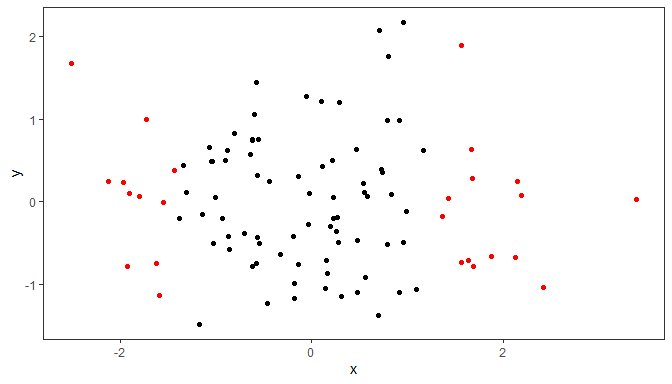

```r
ggplot(data = d, aes(x, y)) +
  geom_point() +
  stat_dens1d_filter(keep.fraction = 0.25,
                     colour = "red")
```

We repeat the example above, we highlight 1/4 of observations, but now from lowest density region along the *y* axis of the plot panel.

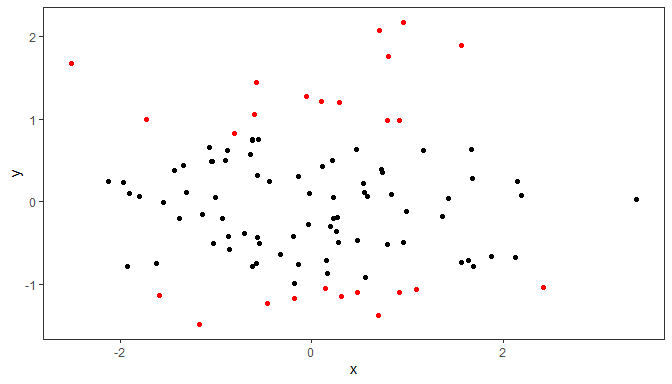

```r
ggplot(data = d, aes(x, y)) +
  geom_point() +
  stat_dens1d_filter(keep.fraction = 0.25,
                     colour = "red",
                     orientation = "y")
```

In other respects than `orientation` and the parameters passed internally to `stats::density()` the examples given earlier for `stat_dens2d_filter()` also apply.

The stat `stat_dens1d_labels` *replaces* the values of the label (aesthetic) variable in `data` based on density of observations along the *x* or *y* axis in the plot panel. The replacement is given by the argument passed to `label.fill`, which can be a character string or a function accepting a character string as argument and returning also a character string.

The default value for `geom` is `"text"`. The default value of `label.fill` is `""` which results in empty labels, while using `NA` as fill label results in observations being omitted. Using `NA` as `label.fill` is similar to using `stat_dens2d_filter` as long as the geom used requires a `label` aesthetic.

In other respects than `orientation` and the parameters passed internally to `stats::density()` the examples given earlier for `stat_dens2d_labels()` also apply.

## Simple position functions

While *jitter* and *dodge* are normally use to displace the observations being plotted to avoid overlaps and *stack* used to construct columns or areas that represent sums and contributions to a sum from different groups of observations, *nudge* is almost always used to displace the position of data labels relative to observations they are attached to, to avoid overlaps.

Nudging shifts deterministically the coordinates giving an *x* and/or *y* position and also expands the limits of the corresponding scales to match. By default in ‘ggplot2’ geometries and position functions no nudging is applied.

Function `position_nudge()` from package ‘ggplot2’ simply applies the nudge, or *x* and/or *y* shifts based directly on the values passed to its parameters `x` and `y`. Passing arguments to the `nudge_x` and/or `nudge_y` parameters of a geometry has the same effect as these values are passed to `position_nudge()`. Geometries also have a `position` parameter to which we can pass an expression based on a *position function* which opens the door to more elaborate approaches to nudging.

A new variation on simple nudge is provided by function `position_nudge_to()`, which accepts the desired nudged final coordinates directly instead of as a shift.

We can do better than simply shifting all data to the same extent and direction or to a fixed position. For example by nudging away from a focal point, a line or a curve. In `position_nudge_center()` and `position_nudge_line()` described below, this reference alters only the direction (angle) along which nudge is applied but not the extent of the shift. Advanced nudging works very well, but only for some patterns of observations and may require manual adjustment of positions, repulsion is more generally applicable but like jitter is aleatory. Combining nudging and repulsion we can make repulsion more predictable with little loss of its applicability.

These functions can be used with any geometry but if segments joining the labels to the points are desired, layer functions `geom_text_s()`, `geom_label_s()`, etc., from ‘ggpp’ or `geom_text_repel()` or `geom_label_repel()` feom ‘ggrepel’ have to be used.

Several geometries defined in package ‘ggpp’ even if not supporting repulsion, can plot connecting segments. Please see the documentation for the geometries for the details. Drawing of segments or arrows is possible if both the nudged and original *x* and *y* coordinates are stored in `data`. Support of this feature across packages is possible by coordinated development of ‘ggpp’ and ‘ggrepel’ and agreement on a naming convention for storing the original position in position functions as those described next.

Simple position functions defined in package ‘ggpp’

| Position | Main use | Displacement | Most used with |
| --- | --- | --- | --- |
| `position_nudge_keep()` | nudge | x, y (fixed distance) | data labels |
| `position_jitter_keep()` | jitter | x, y (random) | dot plots |
| `position_stack_keep()` | stack | vertical (absolute) | column and bar plots |
| `position_stack_minmax()` | stack | vertical (absolute) | error bars |
| `position_fill_keep()` | fill | vertical (relative, fractional) | column plots |
| `position_dodge_keep()` | dodge | sideways (absolute) | column and bar plots |
| `position_dosge2_keep()` | dodge2 | sideways (absolute) | box plots |
| `position_nudge_to()` | nudge | x, y (fixed position) | data labels |
| `position_nudge_center()` | nudge | x, y (away or towards target) | data labels |
| `position_nudge_line()` | nudge | x, y (away or towards target) | data labels |

### position_nudge_keep() and friends

Function `position_nudge_keep()` is like `ggplot2::position_nudge()` but keeps (stores) the original *x* and *y* coordinates; `position_nudge_keep()` can be used interchangeably with `ggplot2::position_nudge()` with other geometries. Although possibly only occasionally needed, `position_jitter_keep()` , `position_dodge_keep()` and `position_stack_keep()` are also made available for completeness.

```r
set.seed(84532)
df <- data.frame(
  x = rnorm(20),
  y = rnorm(20, 2, 2),
  l = paste("label:", letters[1:20])
)
```

When used together with `geom_text_s()` or `geom_label_s()` segments between a nudged label and the original position (here indicated by a point) are drawn.

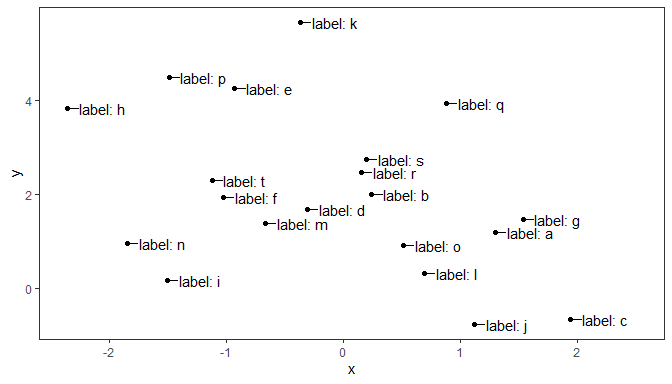

```r
ggplot(df, aes(x, y, label = l)) +
  geom_point() +
  geom_text_s(position = position_nudge_keep(x = 0.1)) +
  expand_limits(x = 2.5)
```

We can supress the drawing of segments.

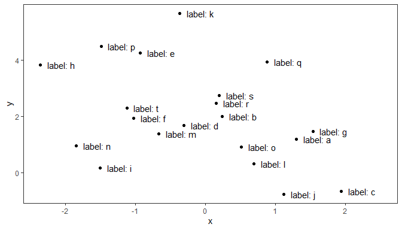

```r
ggplot(df, aes(x, y, label = l)) +
  geom_point() +
  geom_text_s(position = position_nudge_keep(x = 0.1), add.segments = FALSE) +
  expand_limits(x = 2.5)
```

`position_nudge_keep()` and all other position functions described below save the original positions in `data` in columns `x_orig` and `y_orig` and the shifted positions in columns `x` and `y`. Because of this, they can be used together with any ‘ggplot2’ geometry, even though these geometries will ignore the stored original positions.

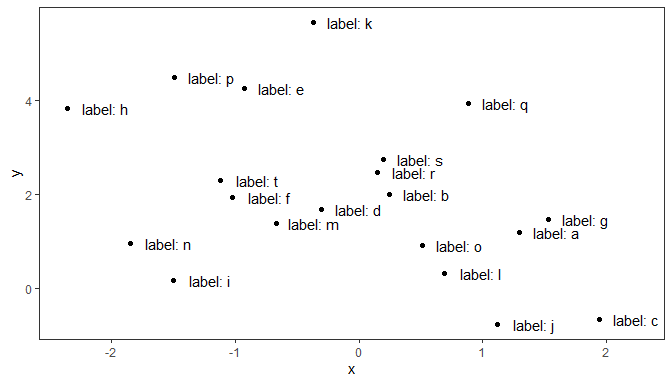

```r
ggplot(df, aes(x, y, label = l)) +
  geom_point() +
  geom_text(position = position_nudge(x = 0.3))
```